# W3cubDocs

/Matplotlib 3.5

# matplotlib.axes.Axes.quiver

**Axes.quiver(*args, *data=None*, **kwargs)[[source]](https://github.com/matplotlib/matplotlib/blob/v3.5.1/lib/matplotlib/axes/_axes.py#L4982-L4991)**

Plot a 2D field of arrows.

Call signature:

```
quiver([X, Y], U, V, [C], **kw)
```

*X*, *Y* define the arrow locations, *U*, *V* define the arrow directions, and *C* optionally sets the color.

Each arrow is internally represented by a filled polygon with a default edge linewidth of 0. As a result, an arrow is rather a filled area, not a line with a head, and `PolyCollection` properties like *linewidth*, *linestyle*, *facecolor*, etc. act accordingly.

**Arrow size**

The default settings auto-scales the length of the arrows to a reasonable size. To change this behavior see the *scale* and *scale_units* parameters.

**Arrow shape**

The defaults give a slightly swept-back arrow; to make the head a triangle, make *headaxislength* the same as *headlength*. To make the arrow more pointed, reduce *headwidth* or increase *headlength* and *headaxislength*. To make the head smaller relative to the shaft, scale down all the head parameters. You will probably do best to leave minshaft alone.

**Arrow outline**

*linewidths* and *edgecolors* can be used to customize the arrow outlines.

**Parameters**

**X, Y**1D or 2D array-like, optional**

The x and y coordinates of the arrow locations.

If not given, they will be generated as a uniform integer meshgrid based on the dimensions of *U* and *V*.

If *X* and *Y* are 1D but *U*, *V* are 2D, *X*, *Y* are expanded to 2D using `X, Y = np.meshgrid(X, Y)`. In this case `len(X)` and `len(Y)` must match the column and row dimensions of *U* and *V*.

**U, V**1D or 2D array-like**

The x and y direction components of the arrow vectors.

They must have the same number of elements, matching the number of arrow locations. *U* and *V* may be masked. Only locations unmasked in *U*, *V*, and *C* will be drawn.

**C**1D or 2D array-like, optional**

Numeric data that defines the arrow colors by colormapping via *norm* and *cmap*.

This does not support explicit colors. If you want to set colors directly, use *color* instead. The size of *C* must match the number of arrow locations.

**units**{'width', 'height', 'dots', 'inches', 'x', 'y', 'xy'}, default: 'width'**

The arrow dimensions (except for *length*) are measured in multiples of this unit.

The following values are supported:

- 'width', 'height': The width or height of the axis.
- 'dots', 'inches': Pixels or inches based on the figure dpi.
- 'x', 'y', 'xy': *X*, *Y* or $\sqrt{X^2 + Y^2}$ in data units.

The arrows scale differently depending on the units. For 'x' or 'y', the arrows get larger as one zooms in; for other units, the arrow size is independent of the zoom state. For 'width or 'height', the arrow size increases with the width and height of the axes, respectively, when the window is resized; for 'dots' or 'inches', resizing does not change the arrows.

**angles**{'uv', 'xy'} or array-like, default: 'uv'**

Method for determining the angle of the arrows.

- 'uv': The arrow axis aspect ratio is 1 so that if *U* == *V* the orientation of the arrow on the plot is 45 degrees counter-clockwise from the horizontal axis (positive to the right).

  Use this if the arrows symbolize a quantity that is not based on *X*, *Y* data coordinates.
- 'xy': Arrows point from (x, y) to (x+u, y+v). Use this for plotting a gradient field, for example.
- Alternatively, arbitrary angles may be specified explicitly as an array of values in degrees, counter-clockwise from the horizontal axis.

  In this case *U*, *V* is only used to determine the length of the arrows.

Note: inverting a data axis will correspondingly invert the arrows only with `angles='xy'`.

**scale**float, optional**

Number of data units per arrow length unit, e.g., m/s per plot width; a smaller scale parameter makes the arrow longer. Default is *None*.

If *None*, a simple autoscaling algorithm is used, based on the average vector length and the number of vectors. The arrow length unit is given by the *scale_units* parameter.

**scale_units**{'width', 'height', 'dots', 'inches', 'x', 'y', 'xy'}, optional**

If the *scale* kwarg is *None*, the arrow length unit. Default is *None*.

e.g. *scale_units* is 'inches', *scale* is 2.0, and `(u, v) = (1, 0)`, then the vector will be 0.5 inches long.

If *scale_units* is 'width' or 'height', then the vector will be half the width/height of the axes.

If *scale_units* is 'x' then the vector will be 0.5 x-axis units. To plot vectors in the x-y plane, with u and v having the same units as x and y, use `angles='xy', scale_units='xy', scale=1`.

**width**float, optional**

Shaft width in arrow units; default depends on choice of units, above, and number of vectors; a typical starting value is about 0.005 times the width of the plot.

**headwidth**float, default: 3**

Head width as multiple of shaft width.

**headlength**float, default: 5**

Head length as multiple of shaft width.

**headaxislength**float, default: 4.5**

Head length at shaft intersection.

**minshaft**float, default: 1**

Length below which arrow scales, in units of head length. Do not set this to less than 1, or small arrows will look terrible!

**minlength**float, default: 1**

Minimum length as a multiple of shaft width; if an arrow length is less than this, plot a dot (hexagon) of this diameter instead.

**pivot**{'tail', 'mid', 'middle', 'tip'}, default: 'tail'**

The part of the arrow that is anchored to the *X*, *Y* grid. The arrow rotates about this point.

'mid' is a synonym for 'middle'.

**color**color or color sequence, optional**

Explicit color(s) for the arrows. If *C* has been set, *color* has no effect.

This is a synonym for the `PolyCollection` *facecolor* parameter.

**Returns**

**`Quiver`**

**Other Parameters**

**data**indexable object, optional**

If given, all parameters also accept a string `s`, which is interpreted as `data[s]` (unless this raises an exception).

**kwargs`PolyCollection` properties, optional**

All other keyword arguments are passed on to `PolyCollection`:

| Property | Description |
| --- | --- |
| `agg_filter` | a filter function, which takes a (m, n, 3) float array and a dpi value, and returns a (m, n, 3) array |
| `alpha` | array-like or scalar or None |
| `animated` | bool |
| `antialiased` or aa or antialiaseds | bool or list of bools |
| `array` | array-like or None |
| `capstyle` | `CapStyle` or {'butt', 'projecting', 'round'} |
| `clim` | (vmin: float, vmax: float) |
| `clip_box` | `Bbox` |
| `clip_on` | bool |
| `clip_path` | Patch or (Path, Transform) or None |
| `cmap` | `Colormap` or str or None |
| `color` | color or list of rgba tuples |
| `edgecolor` or ec or edgecolors | color or list of colors or 'face' |
| `facecolor` or facecolors or fc | color or list of colors |
| `figure` | `Figure` |
| `gid` | str |
| `hatch` | {'/', '\', '\|', '-', '+', 'x', 'o', 'O', '.', '*'} |
| `in_layout` | bool |
| `joinstyle` | `JoinStyle` or {'miter', 'round', 'bevel'} |
| `label` | object |
| `linestyle` or dashes or linestyles or ls | str or tuple or list thereof |
| `linewidth` or linewidths or lw | float or list of floats |
| `norm` | `Normalize` or None |
| `offset_transform` | `Transform` |
| `offsets` | (N, 2) or (2,) array-like |
| `path_effects` | `AbstractPathEffect` |
| `paths` | list of array-like |
| `picker` | None or bool or float or callable |
| `pickradius` | float |
| `rasterized` | bool |
| `sizes` | ndarray or None |
| `sketch_params` | (scale: float, length: float, randomness: float) |
| `snap` | bool or None |
| `transform` | `Transform` |
| `url` | str |
| `urls` | list of str or None |
| `verts` | list of array-like |
| `verts_and_codes` | unknown |
| `visible` | bool |
| `zorder` | float |

See also

**`Axes.quiverkey`**

Add a key to a quiver plot.

## Examples using `matplotlib.axes.Axes.quiver`

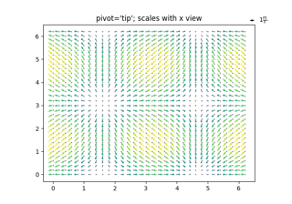

[Advanced quiver and quiverkey functions](https://matplotlib.org/3.5.1/gallery/images_contours_and_fields/quiver_demo.html#sphx-glr-gallery-images-contours-and-fields-quiver-demo-py)

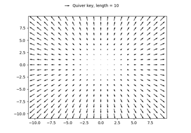

[Quiver Simple Demo](https://matplotlib.org/3.5.1/gallery/images_contours_and_fields/quiver_simple_demo.html#sphx-glr-gallery-images-contours-and-fields-quiver-simple-demo-py)

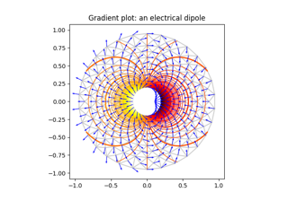

[Trigradient Demo](https://matplotlib.org/3.5.1/gallery/images_contours_and_fields/trigradient_demo.html#sphx-glr-gallery-images-contours-and-fields-trigradient-demo-py)

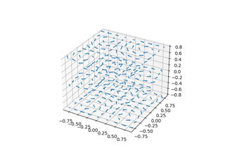

[3D quiver plot](https://matplotlib.org/3.5.1/gallery/mplot3d/quiver3d.html#sphx-glr-gallery-mplot3d-quiver3d-py)

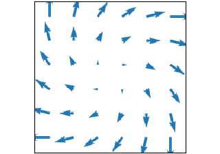

[quiver(X, Y, U, V)](https://matplotlib.org/3.5.1/plot_types/arrays/quiver.html#sphx-glr-plot-types-arrays-quiver-py)

© 2012–2021 Matplotlib Development Team. All rights reserved.  
Licensed under the Matplotlib License Agreement.  
https://matplotlib.org/3.5.1/api/_as_gen/matplotlib.axes.Axes.quiver.html